# Practical Machine Learning Course Project

jleonard07

August 13, 2017

## Executive Summary

The purpose of this project was to build a model in order to predict the manner in which an individual performed an exercise. The data used to build this model came from the **Weight Lifting Exercises Dataset** provided by [Groupware@LES](http://groupware.les.inf.puc-rio.br/har).

The following steps were undertaken to build this model:

1. Investigating training data set
2. Exploratory analysis
3. Variable selection
4. Model selection
5. Model development and validation

A majority of the work involved was in steps 1 and 2.

## Investigating Training Data Set

The main purpose of this step was to identify if there were any variables that could be immediately dropped from the process (e.g., due to missings) prior to **exploratory analysis**. The table consisted of 160 variables and, in an effort to streamline the exploratory analysis, the hope was to reduce this number.

Only the training data set was brought in for review:

```r
origTraining <- read.table("./pml-training.csv", sep = ",", header = TRUE)

str(origTraining)
```

The information provided from the **str** function suggested which variables might have a large number of NAs or missing (i.e., ‘empty’) values. The following code below is an example of a *numeric* variable (min_roll_dumbbell) being analyzed:

```r
# Step 1 - Review summary table of high NA variable and get a count of
# number of NAs
summary(origTraining$min_roll_dumbbell)

# Step 2 - Calculate percent NA
perNA1 <- sum(is.na(origTraining$min_roll_dumbbell))/nrow(origTraining)
perNA1

sum(is.na(origTraining$min_roll_dumbbell))
```

The above code was performed on all numeric and integer variables. The code below was used to assess the variable that were factor but contained missing or odd values (#DIV/0!):

```r
# Step 1 - Review summary table of factor variable and get a sense
# to number of missing
summary(origTraining$skewness_roll_dumbbell)

# Step 2 - Subset data frame by accounts that have missing values for
# factor.
remainingRow <- origTraining[origTraining$skewness_roll_dumbbell != '',]

# Calculate percent (note: since removing the missing we have to do
# 1 - remaining to get percent missing)
perNA2 <- 1 - (nrow(remainingRow)/nrow(origTraining))
perNA2
```

It was determined that variables with a large percent *(75% or more)* of NA or missing values would be excluded from the analysis. Given the analysis of the above a large number of variables could be removed from the training data because of their high number of NAs or missing values.

A majority of these variables had statistical metrics assigned to their name, e.g., avg or min or max. Therefore, the code below identifies these variables and removes them from the training table.

```r
# This greps for variables that, after using str(), appear to be mostly NA
reviewTrain1 <- origTraining[grep("^avg_|^stddev_|^var_|^min_|^max_|^amplitude_|^kurtosis_|^skewness_", names(origTraining))]

# Uses str() on the resulting table to confirm most are NA
str(reviewTrain1)

# Identify variables that met grep condition
toDropVars1 <- names(reviewTrain1)

# Remove variables from the training data set
modTrain1 <- origTraining[, !colnames(origTraining) %in% toDropVars1]
```

After dropping the above variables a review of the data occurred. There were a few variables related to time that were removed from the table because, given the nature of the data and the purpose of the prediciton algorithm, it did not seem appropriate to consider a time series element.

```r
# Date variables removed
toDropVars2 <- c("cvtd_timestamp", "raw_timestamp_part_2", "raw_timestamp_part_1")

# Remove from training data
modTrain2 <-  modTrain1[, !colnames(modTrain1) %in% toDropVars2]
```

A final training table was created containing 57 variables (down from the original 160) of mostly numeric and interger variables. For consistency sake, it is noted now (although anlaysis came later) that the variable **new_window** found from **nearZeroVar** and the variable **user_name** from summary distribution analysis could be removed.

```r
# user_name across classe found mostly equal distribution
toDropVars3 <- c("new_window", "user_name")
modTrain3 <- modTrain2[, !colnames(modTrain2) %in% toDropVars3]
str(modTrain3)
```

## Exploratory Data Analysis

After the training data set had over 100 variables reduced given the steps above, it was time to perform exploratory data analysis. The purpose of this was to:

1. Identify outliers
2. Identify patterns (i.e., non-linearity) that could determine the type of prediction algorithm to use
3. Identfy variables that behave differently across **classe** groups

To accomplish this these steps were taken:

1. Feature plots were built for similar variables (e.g., gyros belt data on x/y/z axis plotted together with classe)
2. Box plots were performed on similiar variables to identify variance across classe groups
3. Histograms were used to identify normality or other behavior.

The below is an example of the code used for the **feature plot**. Note the non-linear relationship across some of the variables (**classe** colors the data points).

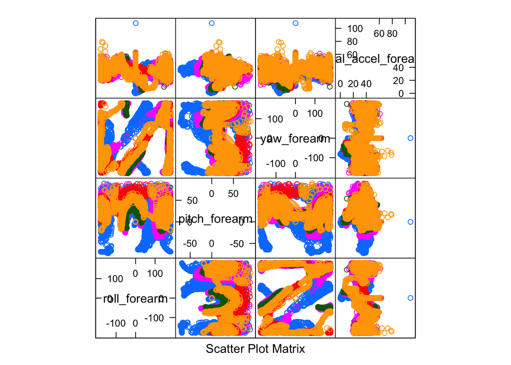

```r
# Look at FOREARM data
forearmData1 <- modTrain3[grep("_forearm", names(modTrain3))]

forearmData2 <- cbind(forearmData1, modTrain3$classe)

# Roll/pitch/yaw/total_acc -- yaw/pitch/row have odd behavior
featurePlot(x=forearmData2[,1:4],
            y = forearmData2[,14],
            plot="pairs")
```

Box-plots were used to determine which variables might be good at separting out impacts on the **classe** variable. The code below is an example of what was used. Note: this particular variable (*magnet_belt_z*) appears to have greater variability for groups **D** and **EE**.

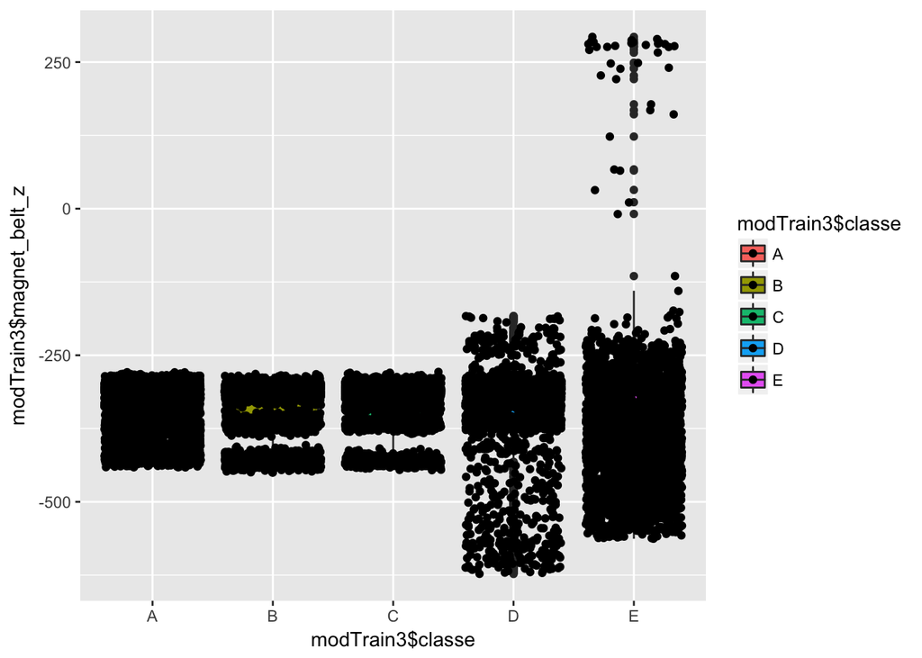

```r
p1 <- qplot(modTrain3$classe,
            modTrain3$magnet_belt_z,
            data=modTrain3,
            fill=modTrain3$classe,
            geom=c("boxplot","jitter"))
p1
```

As with box-plots, the histograms show the amount of volatility that certain variables have for different **classe** values. Those histograms that show different behavior among the **classe** groups suggest they will probably be good to include in model. Note the difference in patterns amongst the groups.

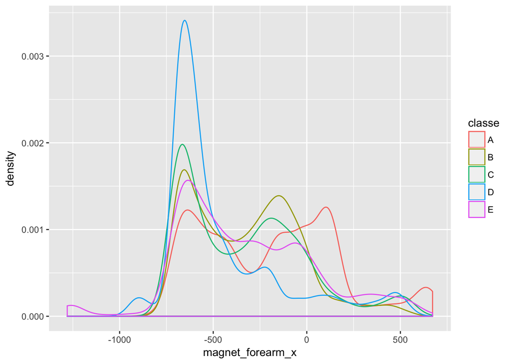

```r
qplot(magnet_forearm_x,colour=classe,data=modTrain3,geom="density")
```

One final graph is going to be shown - that of the variable **X**. I was unable to access the website for a data dictionary (if there is one) but I found the behavior of this variable odd. After thinking about it I reached the conclusion that this variable is a “row number” and indicates how the **classe group** was being loaded into the data set (i.e., one group at a time). *To include this variable into the analysis would give false strength to the model - while there is a relationship it would be useless for prediction*.

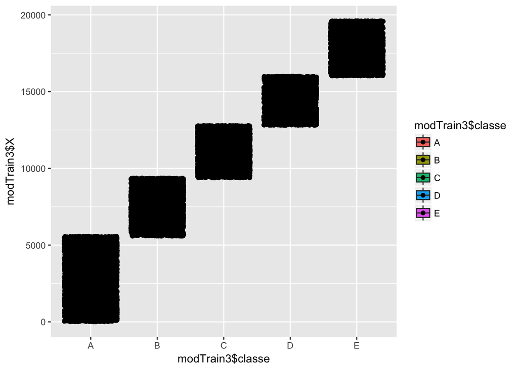

```r
p1 <- qplot(modTrain3$classe,
            modTrain3$X,
            data=modTrain3,
            fill=modTrain3$classe,
            geom=c("boxplot","jitter"))
p1
```

## Variable Selection

From the above analysis it was noted that there were a couple of observations that contained outlier information. They were excluded from the training set.

```r
# Remove observations with outliers in the variables gyros_forearm_y and
# gyros_forearm_z
modTrain4 <- filter(modTrain3, gyros_forearm_y < 8 | gyros_forearm_z < 9)
nrow(modTrain4)

# Remove observations with outliers in the variables magnet_dumbbell_y
modTrain5 <- filter(modTrain4, magnet_dumbbell_y > -3000)
nrow(modTrain5)
```

In addition, the above analysis also allowed a final set of variables to be identified. Those variables can be seen in the code below:

```r
finalKeepVars = c("roll_belt", "gyros_belt_y", "gyros_belt_z", "accel_belt_x",
                  "accel_belt_z", "magnet_belt_y", "magnet_belt_z", "roll_forearm",
                  "pitch_forearm", "magnet_forearm_x", "magnet_forearm_z", "gyros_arm_y",
                  "accel_dumbbell_x", "accel_dumbbell_z", "magnet_dumbbell_x",
                  "magnet_dumbbell_z", "total_accel_dumbbell", "classe")

training <- modTrain5[, colnames(modTrain5) %in% finalKeepVars]
str(training)
```

In summary, the data set being used for building the model contains:

1. 17 predictor variables (down from 159)
2. 19,620 observations (down from 19,622)

## Model Selection

It was determined that a **Random Forest** algorithm would be used for building the model and prediction purposes. It was chosen because:

1. It uses decision trees which are non-linear models and there is evidence of non-linearity in the data
2. The dependent variable is a factor variable
3. Data transformations are not important so no need to do normalization or box-cox transforms
4. Its accuracy strength

## Model Build and Validation

The following code was used to build the random forest predictor. Due to the concern of overfitting k-folds cross validation was used (the **fitControl** object). The number of folds was set to 10 in order to reduce the bias.

```r
set.seed(8675309)

# Specifies k-folds cross validation
fitControl <- trainControl(method = "cv", number = 10)

rfModFit <- train(classe ~ ., data = training,
                  method = "rf",
                  trControl = fitControl,
                  prox = FALSE)
```

A summary of the model information can be found below along with the confusion matrix output:

```r
rfModFit
```

```
## Random Forest
##
## 19620 samples
##    17 predictor
##     5 classes: 'A', 'B', 'C', 'D', 'E'
##
## No pre-processing
## Resampling: Cross-Validated (10 fold)
## Summary of sample sizes: 17658, 17658, 17658, 17659, 17659, 17657, ...
## Resampling results across tuning parameters:
##
##   mtry  Accuracy   Kappa
##    2    0.9850146  0.9810436
##    9    0.9866965  0.9831735
##   17    0.9832310  0.9787909
##
## Accuracy was used to select the optimal model using  the largest value.
## The final value used for the model was mtry = 9.
```

```r
predictTrain <- predict(rfModFit, newdata=training)
confusionMatrix(training$classe, predictTrain)
```

```
## Confusion Matrix and Statistics
##
##           Reference
## Prediction    A    B    C    D    E
##          A 5579    0    0    0    0
##          B    0 3796    0    0    0
##          C    0    0 3422    0    0
##          D    0    0    0 3216    0
##          E    0    0    0    0 3607
##
## Overall Statistics
##
##                Accuracy : 1
##                  95% CI : (0.9998, 1)
##     No Information Rate : 0.2844
##     P-Value [Acc > NIR] : < 2.2e-16
##
##                   Kappa : 1
##  Mcnemar's Test P-Value : NA
##
## Statistics by Class:
##
##                      Class: A Class: B Class: C Class: D Class: E
## Sensitivity            1.0000   1.0000   1.0000   1.0000   1.0000
## Specificity            1.0000   1.0000   1.0000   1.0000   1.0000
## Pos Pred Value         1.0000   1.0000   1.0000   1.0000   1.0000
## Neg Pred Value         1.0000   1.0000   1.0000   1.0000   1.0000
## Prevalence             0.2844   0.1935   0.1744   0.1639   0.1838
## Detection Rate         0.2844   0.1935   0.1744   0.1639   0.1838
## Detection Prevalence   0.2844   0.1935   0.1744   0.1639   0.1838
## Balanced Accuracy      1.0000   1.0000   1.0000   1.0000   1.0000
```

While the model shows a good fit on the training data (possibly overfitting) an estimate of the error rate can be obtained. For random forest to get an unbiased estimate of test set error one use the **out-of-bag (oob)** error estimate. The code below shows how to obtain this out of sample error (i.e., **1.21%**):

```r
rfModFit$finalModel
```

```
##
## Call:
##  randomForest(x = x, y = y, mtry = param$mtry, proximity = FALSE)
##                Type of random forest: classification
##                      Number of trees: 500
## No. of variables tried at each split: 9
##
##         OOB estimate of  error rate: 1.21%
## Confusion matrix:
##      A    B    C    D    E class.error
## A 5563    8    5    2    1 0.002867897
## B   21 3721   42   12    0 0.019757640
## C    2   19 3374   27    0 0.014026885
## D    2    5   55 3150    4 0.020522388
## E    0    3    9   20 3575 0.008871638
```